# EDA - In-Class Lab Exercise (Day 4) - Deepak

|  | Inclass - Lab (Day 4) |
| --- | --- |

### About the data set (Detected Cases of Malaria)

This dataset consists of data for countries with an active malaria outbreak.

Attribute Information:

**Cases_Guinea**: Number of cases of malaria reported from Guinea

**Cases_Liberia**: Number of cases of malaria reported from Liberia

**Cases_SierraLeone**: Number of cases of malaria reported from Sierra Leone

**Cases_Nigeria**: Number of cases of malaria reported from Nigeria

**Cases_Senegal**: Number of cases of malaria reported from Senegal

**Cases_UnitedStates**: Number of cases of malaria reported from the United States of America

**Cases_Spain**: Number of cases of malaria reported from Spain

**Cases_Mali**: Number of cases of malaria reported from Mali

**Deaths_Guinea**: Number of deaths reported out of the detected cases of malaria from Guinea

**Deaths_Liberia**: Number of deaths reported out of the detected cases of malaria from Liberia

**Deaths_SierraLeone**: Number of deaths reported out of the detected cases of malaria from Sierra Leone

**Deaths_Nigeria**: Number of deaths reported out of the detected cases of malaria from Nigeria

**Deaths_Senegal**: Number of deaths reported out of the detected cases of malaria from Senegal

**Deaths_UnitedStates**: Number of deaths reported out of the detected cases of malaria from the United States of America

**Deaths_Spain**: Number of deaths reported out of the detected cases of malaria from Spain

**Deaths_Mali**: Number of deaths reported out of the detected cases of malaria from Mali

## Table of Content

1. **Missing Values Detection**
2. **Handling Missing Values**
3. **Outlier Detection Techniques**
4. **Treatment of Outliers**
5. **Feature Engineering**
6. **Train-Test Split**

**Import the required libraries**

```python
import numpy as np
import pandas as pd
import matplotlib.pyplot as plt
import seaborn as sns
from scipy import stats
from sklearn.preprocessing import LabelEncoder
from sklearn.preprocessing import MinMaxScaler
from sklearn.model_selection import train_test_split
```

#### Load the malaria dataset and display the first five records (Use for section 1, 2)

```python
df1=pd.read_csv('malaria.csv')
df1.head()
```

|  | Cases_Guinea | Cases_Liberia | Cases_SierraLeone | Cases_Nigeria | Cases_Senegal | Cases_UnitedStates | Cases_Spain | Cases_Mali | Deaths_Guinea | Deaths_Liberia | Deaths_SierraLeone | Deaths_Nigeria | Deaths_Senegal | Deaths_UnitedStates | Deaths_Spain | Deaths_Mali |
| --- | --- | --- | --- | --- | --- | --- | --- | --- | --- | --- | --- | --- | --- | --- | --- | --- |
| 0 | 2776.0 | NaN | 10030.0 | NaN | NaN | NaN | NaN | NaN | 1786.0 | NaN | 2977.0 | NaN | NaN | NaN | NaN | NaN |
| 1 | 2775.0 | NaN | 9780.0 | NaN | NaN | NaN | NaN | NaN | 1781.0 | NaN | 2943.0 | NaN | NaN | NaN | NaN | NaN |
| 2 | 2769.0 | 8166.0 | 9722.0 | NaN | NaN | 20.0 | NaN | NaN | 1767.0 | 3496.0 | 2915.0 | NaN | NaN | 3.0 | NaN | NaN |
| 3 | NaN | 8157.0 | NaN | NaN | NaN | 10.0 | NaN | NaN | NaN | 3496.0 | NaN | NaN | NaN | 8.0 | NaN | NaN |
| 4 | NaN | NaN | NaN | NaN | NaN | NaN | NaN | NaN | NaN | NaN | NaN | NaN | NaN | NaN | NaN | NaN |

### Let's begin with some hands-on practice exercises

## 1. Missing Values Detection

|  | **1. Are there any records where no data has been reported?** |
| --- | --- |

```python
df1.isnull().sum()
```

```
Cases_Guinea            34
Cases_Liberia           44
Cases_SierraLeone       40
Cases_Nigeria           89
Cases_Senegal          102
Cases_UnitedStates      54
Cases_Spain            111
Cases_Mali             115
Deaths_Guinea           35
Deaths_Liberia          46
Deaths_SierraLeone      40
Deaths_Nigeria          89
Deaths_Senegal         105
Deaths_UnitedStates     70
Deaths_Spain           111
Deaths_Mali            115
dtype: int64
```

|  | **2. Find a list of all the columns which have more than 60% of their values missing** |
| --- | --- |

```python
df1.isnull().sum()[df1.isnull().sum()/len(df1)*100>60]
```

```
Cases_Nigeria      89
Cases_Senegal     102
Cases_Spain       111
Cases_Mali        115
Deaths_Nigeria     89
Deaths_Senegal    105
Deaths_Spain      111
Deaths_Mali       115
dtype: int64
```

[output not shown]

```python
df1
```

[output not shown]

127 rows × 16 columns

```python
g=df1[['Cases_Guinea','Deaths_Guinea']].isnull().sum().sum()
g
```

[output not shown]

```python
l=df1[['Cases_Liberia','Deaths_Liberia']].isnull().sum().sum()
l
```

```
90
```

```python
s=df1[['Cases_SierraLeone','Deaths_SierraLeone']].isnull().sum().sum()
s
```

```
80
```

```python
n=df1[['Cases_Nigeria','Deaths_Nigeria']].isnull().sum().sum()
n
```

```
178
```

|  | **4. Visualize the missing values in the data** |
| --- | --- |

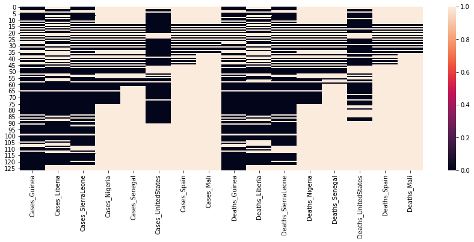

```python
plt.rcParams['figure.figsize']=(15,5)
sns.heatmap(df1.isnull())
plt.show()
```

## 2. Handling Missing Values

|  | **5. Eliminate all the records where no more than two observations have been recorded** |
| --- | --- |

```python
# at least 2 null values
df1.dropna(thresh=2)
```

|  | Cases_Guinea | Cases_Liberia | Cases_SierraLeone | Cases_Nigeria | Cases_Senegal | Cases_UnitedStates | Cases_Spain | Cases_Mali | Deaths_Guinea | Deaths_Liberia | Deaths_SierraLeone | Deaths_Nigeria | Deaths_Senegal | Deaths_UnitedStates | Deaths_Spain | Deaths_Mali |
| --- | --- | --- | --- | --- | --- | --- | --- | --- | --- | --- | --- | --- | --- | --- | --- | --- |
| 0 | 2776.0 | NaN | 10030.0 | NaN | NaN | NaN | NaN | NaN | 1786.0 | NaN | 2977.0 | NaN | NaN | NaN | NaN | NaN |
| 1 | 2775.0 | NaN | 9780.0 | NaN | NaN | NaN | NaN | NaN | 1781.0 | NaN | 2943.0 | NaN | NaN | NaN | NaN | NaN |
| 2 | 2769.0 | 8166.0 | 9722.0 | NaN | NaN | 20.0 | NaN | NaN | 1767.0 | 3496.0 | 2915.0 | NaN | NaN | 3.0 | NaN | NaN |
| 3 | NaN | 8157.0 | NaN | NaN | NaN | 10.0 | NaN | NaN | NaN | 3496.0 | NaN | NaN | NaN | 8.0 | NaN | NaN |
| 5 | 2730.0 | 8115.0 | 9633.0 | NaN | NaN | 7.0 | NaN | NaN | 1739.0 | 3471.0 | 2827.0 | NaN | NaN | 5.0 | NaN | NaN |
| ... | ... | ... | ... | ... | ... | ... | ... | ... | ... | ... | ... | ... | ... | ... | ... | ... |
| 122 | 103.0 | 8.0 | 6.0 | NaN | NaN | NaN | NaN | NaN | 66.0 | 6.0 | 5.0 | NaN | NaN | NaN | NaN | NaN |
| 123 | 86.0 | NaN | NaN | NaN | NaN | NaN | NaN | NaN | 62.0 | NaN | NaN | NaN | NaN | NaN | NaN | NaN |
| 124 | 86.0 | NaN | NaN | NaN | NaN | NaN | NaN | NaN | 60.0 | NaN | NaN | NaN | NaN | NaN | NaN | NaN |
| 125 | 86.0 | NaN | NaN | NaN | NaN | NaN | NaN | NaN | 59.0 | NaN | NaN | NaN | NaN | NaN | NaN | NaN |
| 126 | 49.0 | NaN | NaN | NaN | NaN | NaN | NaN | NaN | 29.0 | NaN | NaN | NaN | NaN | NaN | NaN | NaN |

121 rows × 16 columns

|  | **6. Cast aside the unnecessary columns from the data** |
| --- | --- |

```python
df1.drop(['Cases_Nigeria','Cases_Senegal','Cases_Spain','Cases_Mali','Deaths_Nigeria','Deaths_Senegal','Deaths_Spain','Deaths_Mali'], axis=1)
```

|  | Cases_Guinea | Cases_Liberia | Cases_SierraLeone | Cases_UnitedStates | Deaths_Guinea | Deaths_Liberia | Deaths_SierraLeone | Deaths_UnitedStates |
| --- | --- | --- | --- | --- | --- | --- | --- | --- |
| 0 | 2776.0 | NaN | 10030.0 | NaN | 1786.0 | NaN | 2977.0 | NaN |
| 1 | 2775.0 | NaN | 9780.0 | NaN | 1781.0 | NaN | 2943.0 | NaN |
| 2 | 2769.0 | 8166.0 | 9722.0 | 20.0 | 1767.0 | 3496.0 | 2915.0 | 3.0 |
| 3 | NaN | 8157.0 | NaN | 10.0 | NaN | 3496.0 | NaN | 8.0 |
| 4 | NaN | NaN | NaN | NaN | NaN | NaN | NaN | NaN |
| ... | ... | ... | ... | ... | ... | ... | ... | ... |
| 122 | 103.0 | 8.0 | 6.0 | NaN | 66.0 | 6.0 | 5.0 | NaN |
| 123 | 86.0 | NaN | NaN | NaN | 62.0 | NaN | NaN | NaN |
| 124 | 86.0 | NaN | NaN | NaN | 60.0 | NaN | NaN | NaN |
| 125 | 86.0 | NaN | NaN | NaN | 59.0 | NaN | NaN | NaN |
| 126 | 49.0 | NaN | NaN | NaN | 29.0 | NaN | NaN | NaN |

127 rows × 8 columns

|  | **7. How would you treat the missing values of the reported cases from Liberia?** |
| --- | --- |

```python
l=df1[['Cases_Liberia','Deaths_Liberia']].isnull().sum().sum()
l
df1['Cases_Liberia'].skew()
```

```
0.9491336030709361
```

```python
df1['Cases_Liberia'].fillna(df1['Cases_Liberia'].median())
```

```
0       516.0
1       516.0
2      8166.0
3      8157.0
4       516.0
        ...
122       8.0
123     516.0
124     516.0
125     516.0
126     516.0
Name: Cases_Liberia, Length: 127, dtype: float64
```

|  | **8. How would you treat the missing values from the reported cases of malaria from the United States of America?** |
| --- | --- |

```python
df1['Cases_UnitedStates'].skew()
```

```
0.4685235032170701
```

```python
df1['Cases_UnitedStates'].fillna(df1['Cases_UnitedStates'].mean())
```

```
0      14.068493
1      14.068493
2      20.000000
3      10.000000
4      14.068493
         ...
122    14.068493
123    14.068493
124    14.068493
125    14.068493
126    14.068493
Name: Cases_UnitedStates, Length: 127, dtype: float64
```

|  | **9. How should the missing values from the observations recorded in 'Guinea' be dealt with?** |
| --- | --- |

```python
df1['Cases_Guinea'].skew()
```

```
1.0023009483886705
```

```python
df1['Cases_Guinea'].fillna(df1['Cases_Guinea'].median())
```

```
0      2776.0
1      2775.0
2      2769.0
3       495.0
4       495.0
        ...
122     103.0
123      86.0
124      86.0
125      86.0
126      49.0
Name: Cases_Guinea, Length: 127, dtype: float64
```

## For questions hereon, we shall consider the following dataset.

### About the dataset (House Prices in Melbourne)

The dataset contains different attributes that contribute to the price of the houses in Melbourne.

Attribute Information:

**Rooms**: Number of rooms

**Type**: h - house,cottage,villa, semi,terrace; u - unit, duplex; t - townhouse; dev site - development site; o res - other residential.

**Price**: Price in dollars

**Method**: S - property sold; SP - property sold prior; PI - property passed in; PN - sold prior not disclosed; SN - sold not disclosed; NB - no bid; VB - vendor bid; W - withdrawn before auction; SA - sold after auction; SS - sold after auction price not disclosed. N/A - price or highest bid not available.

**Regionname**: General Region (West, North West, North, Northeast,...)

**Bathroom**: Number of Bathrooms

**Car**: Number of car spots

**Landsize**: Land Size of a house

**Distance**: Distance from CBD (City Centre)

**Bedroom**: Number of Bedrooms

#### Load the house dataset and display the first five records (Use for section 3 to 6)

## 3. Outlier Detection Techniques

|  | **10. Is there a feature in the dataset which could be exempted from outlier treatment?** |
| --- | --- |

```python
df2=pd.read_csv('house.csv')
df2
```

|  | Rooms | Type | Price | Method | Regionname | Bathroom | Car | Landsize | Distance | Bedroom |
| --- | --- | --- | --- | --- | --- | --- | --- | --- | --- | --- |
| 0 | 3 | h | 1490000 | S | Northern Metropolitan | 1 | 1 | 126 | 25.2 | 2 |
| 1 | 3 | h | 1220000 | S | Northern Metropolitan | 1 | 1 | 202 | 21.8 | 2 |
| 2 | 3 | h | 1420000 | S | Northern Metropolitan | 1 | 0 | 156 | 21.7 | 2 |
| 3 | 3 | h | 1515000 | S | Western Metropolitan | 2 | 1 | 0 | 18.8 | 3 |
| 4 | 2 | h | 670000 | S | Western Metropolitan | 2 | 0 | 134 | 20.6 | 3 |
| ... | ... | ... | ... | ... | ... | ... | ... | ... | ... | ... |
| 4761 | 3 | h | 1150000 | VB | Southern Metropolitan | 2 | 1 | 305 | 18.7 | 3 |
| 4762 | 3 | h | 712000 | S | South-Eastern Metropolitan | 1 | 0 | 105 | 16.0 | 4 |
| 4763 | 4 | h | 800000 | S | South-Eastern Metropolitan | 1 | 0 | 120 | 24.5 | 3 |
| 4764 | 3 | u | 747000 | S | South-Eastern Metropolitan | 1 | 1 | 0 | 22.9 | 3 |
| 4765 | 3 | h | 800000 | SP | South-Eastern Metropolitan | 1 | 1 | 0 | 13.7 | 3 |

4766 rows × 10 columns

|  | **11. How do we check the outlier values for the feature representing the number of car spots?** |
| --- | --- |

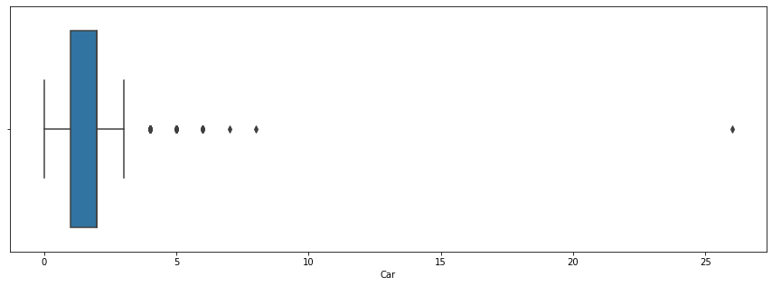

```python
sns.boxplot(data=df2, x='Car')
```

|  | **12. Compare the outliers present in the price of real estates by their type** |
| --- | --- |

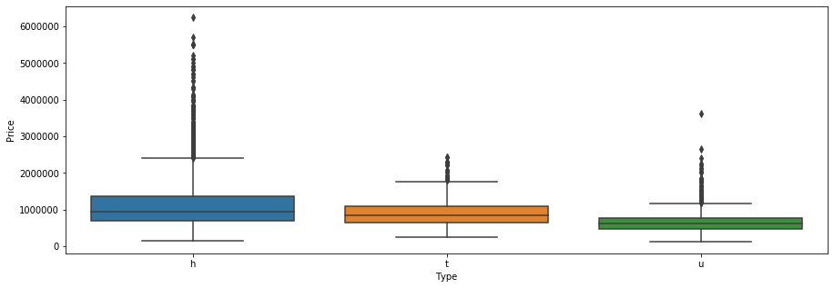

```python
sns.boxplot(data=df2, x='Type',y='Price')
```

|  | **13. What would be the extreme values for the feature representing the number of rooms?** |
| --- | --- |

```python
Q1=df2['Rooms'].quantile(0.25)
Q2=df2['Rooms'].quantile(0.5)
Q3=df2['Rooms'].quantile(0.75)
```

```python
IQR = Q3-Q1
```

```python
UL= Q3+1.5*IQR
LL=Q1-1.5*IQR
print('UL and LL are: ',UL,LL)
```

```
UL and LL are:  7.0 -1.0
```

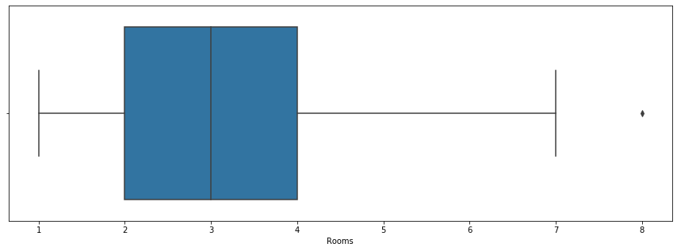

```python
sns.boxplot(data=df2, x='Rooms')
```

```python
df2[df2['Rooms']>7]
```

|  | Rooms | Type | Price | Method | Regionname | Bathroom | Car | Landsize | Distance | Bedroom |
| --- | --- | --- | --- | --- | --- | --- | --- | --- | --- | --- |
| 3073 | 8 | u | 2250000 | PI | Northern Metropolitan | 3 | 2 | 543 | 25.3 | 2 |

|  | **14. Suggest a method to find the outlier values for the feature representing the number of bathrooms** |
| --- | --- |

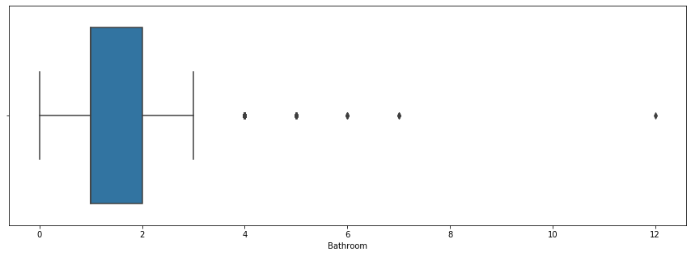

```python
sns.boxplot(data=df2, x='Bathroom')
```

```python
df2[df2['Bathroom']>3]
```

|  | Rooms | Type | Price | Method | Regionname | Bathroom | Car | Landsize | Distance | Bedroom |
| --- | --- | --- | --- | --- | --- | --- | --- | --- | --- | --- |
| 103 | 3 | t | 385000 | S | Northern Metropolitan | 7 | 0 | 435 | 18.0 | 3 |
| 122 | 3 | t | 950000 | S | Eastern Metropolitan | 4 | 4 | 809 | 19.3 | 3 |
| 229 | 1 | u | 337000 | S | South-Eastern Metropolitan | 4 | 2 | 662 | 12.7 | 3 |
| 382 | 3 | h | 720000 | S | Western Metropolitan | 5 | 2 | 755 | 14.0 | 4 |
| 448 | 3 | h | 1116000 | S | Southern Metropolitan | 5 | 4 | 673 | 19.0 | 3 |
| ... | ... | ... | ... | ... | ... | ... | ... | ... | ... | ... |
| 4093 | 2 | u | 560000 | PI | Southern Metropolitan | 4 | 2 | 355 | 11.6 | 3 |
| 4132 | 2 | u | 600000 | S | Southern Metropolitan | 4 | 2 | 636 | 27.2 | 2 |
| 4497 | 4 | h | 1730000 | S | Southern Metropolitan | 4 | 3 | 569 | 23.8 | 3 |
| 4681 | 3 | h | 870000 | VB | Western Metropolitan | 4 | 3 | 188 | 20.4 | 2 |
| 4719 | 2 | u | 780000 | S | Eastern Metropolitan | 4 | 2 | 353 | 18.1 | 4 |

71 rows × 10 columns

|  | **15. Extract the records corresponding to the extreme outliers present in the feature representing the number of bedrooms** |
| --- | --- |

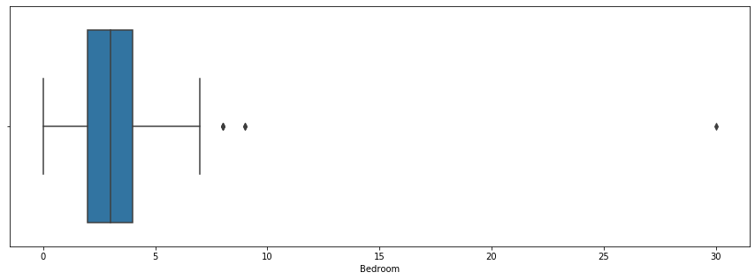

```python
sns.boxplot(data=df2, x='Bedroom')
```

```python
df2[df2['Bedroom']>7]
```

|  | Rooms | Type | Price | Method | Regionname | Bathroom | Car | Landsize | Distance | Bedroom |
| --- | --- | --- | --- | --- | --- | --- | --- | --- | --- | --- |
| 279 | 3 | t | 1100000 | S | Southern Metropolitan | 1 | 1 | 0 | 12.1 | 8 |
| 467 | 2 | u | 612000 | S | South-Eastern Metropolitan | 1 | 2 | 766 | 27.1 | 9 |
| 1228 | 3 | h | 470000 | PI | Western Metropolitan | 2 | 2 | 486 | 20.9 | 9 |
| 1937 | 3 | h | 496000 | S | Western Metropolitan | 1 | 1 | 0 | 21.7 | 30 |
| 4241 | 3 | h | 825000 | S | Eastern Metropolitan | 2 | 2 | 296 | 21.2 | 8 |
| 4249 | 3 | t | 750000 | S | Western Metropolitan | 2 | 0 | 311 | 22.1 | 8 |